# Area is a poor metaphor

Area is a poor metaphor

*A collection of common [dataviz caveats](https://www.data-to-viz.com/caveats.html) by [Data-to-Viz.com](https://www.data-to-viz.com)*

[figure not shown]

# Areas as a measure

The human eye does not perform well when it has to translate areas to numeric values. Let’s consider the following five bubbles. Try to rank them by decreasing area. You will probably agree that this is possible, but takes some time.

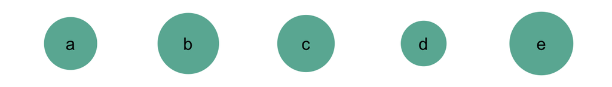

```r
# Libraries
library(tidyverse)
library(hrbrthemes)

# create 3 data frame:
data <- data.frame( name=letters[1:5], value=c(17,24,20,15,27) )

# Plot
ggplot(data, aes(x=name, y=1, size=value)) +
  geom_point(color="#69b3a2") +
  geom_text(aes(label=name), size=5) +
  scale_size_continuous(range=c(17,24)) +
  theme_void() +
  theme(
    legend.position="none"
  ) +
  ylim(0.9,1.1)
```

# Same info, easier to read

Now, let’s represent the exact same values using bars instead:

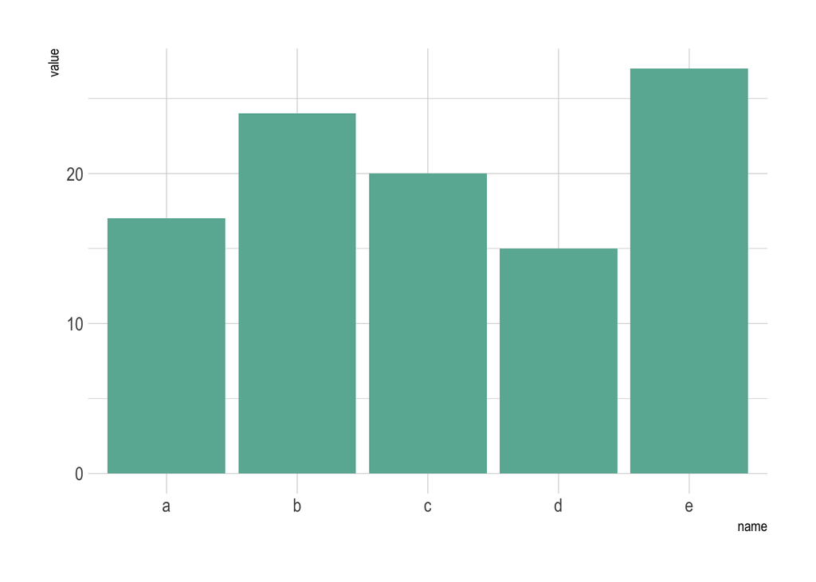

```r
# Plot
ggplot(data, aes(x=name, y=value)) +
  geom_bar(stat="identity", fill="#69b3a2") +
  theme_ipsum()
```

That is much easier, is’nt it?

This does not mean that area must never been used to represent a numeric variable. It means that other shapes and techniques must be before using area. For instance, the [bubble chart](https://www.data-to-viz.com/graph/bubble.html) does a good job representing the values of 3 numeric variables.

# Going further

- Using bubbles: [scaling to radius or area](https://www.data-to-viz.com/caveat/radius_or_area.html)?
- Data visualization: basic principles. [link](http://paldhous.github.io/ucb/2016/dataviz/week2.html)

## Dataviz decision tree

A work by [Yan Holtz](https://github.com/holtzy/) for data-to-viz.com